# DATA319_2024Summer_Midterm_Salmon_John

## DATA 319: Model-based and Data-based Methods for Data Analytics. Summer 2024

### Midterm Exam

##### By signing below you acknowledge that you are a member of a learning community in Washington State University that is committed to the academic standards of respect and integrity, and that you adhered to these standards while completing this exam.

### *John Salmon*

#### 1. Assume that you are operating with a dataset that includes following variables for a large sample of individuals (employees): age, salary, gender, marital status. Provide an appropriate hypothesis test (univariate tests: t-test for one or more samples, ANOVA test for three or more samples (one-factor ANOVA or multi-factor ANOVA); multivariate tests: multivariate $T^2$ test, multivariate ANOVA) for each of the tasks below and briefly (one sentence is enough) justify your choice:

##### (a) Testing that the population mean age of employees equals to some hypothesized value.

I would use a One Sample T Test because we are comparing a single mean, the average age, to a single specified value.

##### (b) Testing simultaneously (at the same time) that the population mean age and population mean salary of employees equals to some respective hypothesized values.

I would use a Multiple variate t^2 Test in this case because we are comparing 2 means, salary and age to some specified values.

##### (c) Testing that the difference between population mean salaries of married vs single employees equals to some hypothesized value (or equals to zero if testing that there is no difference).

I would use a 2 sample t-test because we are comparing the averages of two independent groups, married and single, to a value

##### (d) Testing that the difference between population mean salaries of married male vs married female employees equals to some hypothesized value (or equals to zero if testing that there is no difference). Assume that we managed to sample groups such that we obtained spousal data (male and female employees are husbands and wifes of each other).

I would use a paired t-test because we are looking at means two groups of paired variables, the employees and their spouses and comparing them to a value.

##### (e) Testing that the difference between population mean salaries of married male vs married female employees equals to some hypothesized value (or equals to zero if testing that there is no difference). Assume that we sampled both groups randomly here (i.e. there is no spousal connection between samples).

I would use a 2 sample t test because the groups are independent and don't have a link between them.

##### (f) The gender variable includes also third category "other/prefer not to reveal my gender". Given this, consider testing that there is no difference in population mean ages between these three categories for gender identity.

I would use one-factor anova because there are three gender identity categories.

##### (g) Testing simultaneously (at the same time) that there is no difference both in population mean ages and population mean salaries between these three categories for gender identity.

i would use multivariate anova because we are lookng at the difference in two dependent variables, age and salary between the 3 gender identites.

##### (h) Testing that there is no difference in population mean salaries between the groups differing both by their gender identity and their marital status.

I would use two factor anova because marital status and salary are independent from one another and we want to separate it by the 3 possible gender identites.

##### (b) for each pair of the following three bags (Jaccard bag similarity): $\{1, 1, 2, 2\}$, $\{1, 1, 1, 2, 3\}$, and $\{1, 2, 3, 4\}$.

AB = 0.66 AC = 0.5 BC = 0.75

*Note that you are encouraged but not required to use Python to obtain the answers for these questions. If you opt out from using Python in favor of "paper-and-pencil" (i.e. no coding involved) approach, then show your work to get full credit (reporting just answers will not be sufficient)*

```python
#Q2
SetA = {1,2,3,4}
SetB = {3,4,5,6}
SetC = {2,4,5}

#Jaccard Set Similarity
JaccardAB = len(SetA.intersection(SetB)) / len(SetA.union(SetB))
JaccardAC = len(SetA.intersection(SetC)) / len(SetA.union(SetC))
JaccardBC = len(SetB.intersection(SetC)) / len(SetB.union(SetC))

from collections import Counter
Bag1 = Counter([1,1,2,2])
Bag2 = Counter([1,1,1,2,3])
Bag3 = Counter([1,2,3,4])

#Jaccard Bag Similarity
Jaccard12 = len(Counter(Bag1) & Counter(Bag2)) / len(Counter(Bag1) | Counter(Bag2))
Jaccard13 = len(Counter(Bag1) & Counter(Bag3)) / len(Counter(Bag1) | Counter(Bag3))
Jaccard23 = len(Counter(Bag2) & Counter(Bag3)) / len(Counter(Bag2) | Counter(Bag3))

print(f"Jaccard Set Similarity: {JaccardAB}, {JaccardAC}, {JaccardBC}")
print(f"Jaccard Bag Similarity: {Jaccard12}, {Jaccard13}, {Jaccard23}")
```

```
Jaccard Set Similarity: 0.3333333333333333, 0.4, 0.4
Jaccard Bag Similarity: 0.6666666666666666, 0.5, 0.75
```

#### 3. Suppose there are 100 items, numbered 1 to 100, and also 100 baskets, also numbered 1 to 100. Item i is in basket b if and only if i divides b with no remainder. Thus, item 1 is in all the baskets, item 2 is in all fifty of the even-numbered baskets, and so on. Basket 12 consists of items $\{1, 2, 3, 4, 6, 12\}$, since these are all the integers that divide 12. Answer the following questions:

##### (a) If the basket is a prime number, how many items will it consist of?

2 items

##### (b) Which basket is the largest (i.e. it consists of the largest count of items)?

Basket 100 Has the most number of items in it.

##### (c) If the support threshold is 6, which items are frequent?

[1, 2, 3, 4, 5, 6, 7, 8, 9, 10, 11, 12, 13, 14]

##### (d) Apply the A-Priori Algorithm with support threshold 6 to this data to determine all frequent itemsets.

See Code Below

##### (e) What is the interest of the following association rules?

i. $\{5, 7\}\rightarrow2$ = 0.5

ii. $\{2, 3, 4\}\rightarrow5$ = 0.125

*Note that you are encouraged but not required to use Python to obtain the answers for these questions. If you opt out from using Python in favor of "paper-and-pencil" (i.e. no coding involved) approach, then show your work to get full credit (reporting just answers will not be sufficient)*

```python
#question 3
from collections import Counter
baskets = [[i for i in range(1,101) if b % i == 0] for b in range(1,101)]
flat_baskets = [item for basket in baskets for item in basket]
counts = Counter(flat_baskets)

#A
primes = []
for n in range(1, 101):
    if n > 1:
        for i in range(2, int(n**0.5) + 1):
            if (n % i) == 0:
                break
        else:
            primes.append(n)

prime_basket_counts = {prime: len(baskets[prime-1]) for prime in primes}

for prime, count in prime_basket_counts.items():
    print(f"Prime Number {prime} Basket has {count} items.")

#B
Max = 0
largest_basket = 0

for n in range(1, 101):
    divisors = [i for i in range(1, n + 1)]
    if len(divisors) > Max:
        Max = len(divisors)
        largest_basket = n

print(f"Largest Basket: {largest_basket}")

#C
frequent_itemsets = [item for item, count in counts.items() if count > 6]
print(f"\nFrequent Itemsets: {frequent_itemsets}")

#D
from mlxtend.preprocessing import TransactionEncoder
from mlxtend.frequent_patterns import apriori
import pandas as pd
pd.set_option('display.max_rows', None)
te = TransactionEncoder()
te_ary = te.fit(baskets).transform(baskets)
df = pd.DataFrame(te_ary, columns=te.columns_)

priori_sets = apriori(df, min_support = 0.06, use_colnames = True)
priori_sets['length'] = priori_sets['itemsets'].apply(lambda x: len(x))
priori_sets = priori_sets[priori_sets['length'] >= 6].reset_index(drop = False)
print(f"\nApriori Frequent Sets: {priori_sets}")

#E
def cal_sup(itemset, baskets):
    count = sum(1 for basket in baskets if all(item in basket for item in itemset))
    return count / len(baskets)

#i
sup_5_7 = cal_sup({5, 7}, baskets)
sup_2 = cal_sup({2}, baskets)
sup_5_7_2 = cal_sup({5, 7, 2}, baskets)
interest = sup_5_7_2 / sup_5_7
print(f"\nInterest 5, 7 -> 2: {interest}")


#ii
sup_2_3_4 = cal_sup({2, 3, 4}, baskets)
sup_5 = cal_sup({5}, baskets)
sup_2_3_4_5 = cal_sup({2, 3, 4, 5}, baskets)
interest = sup_2_3_4_5 / sup_2_3_4
print(f"Interest 2, 3, 4 -> 5: {interest}")
```

```
Prime Number 2 Basket has 2 items.
Prime Number 3 Basket has 2 items.
Prime Number 5 Basket has 2 items.
Prime Number 7 Basket has 2 items.
Prime Number 11 Basket has 2 items.
Prime Number 13 Basket has 2 items.
Prime Number 17 Basket has 2 items.
Prime Number 19 Basket has 2 items.
Prime Number 23 Basket has 2 items.
Prime Number 29 Basket has 2 items.
Prime Number 31 Basket has 2 items.
Prime Number 37 Basket has 2 items.
Prime Number 41 Basket has 2 items.
Prime Number 43 Basket has 2 items.
Prime Number 47 Basket has 2 items.
Prime Number 53 Basket has 2 items.
Prime Number 59 Basket has 2 items.
Prime Number 61 Basket has 2 items.
Prime Number 67 Basket has 2 items.
Prime Number 71 Basket has 2 items.
Prime Number 73 Basket has 2 items.
Prime Number 79 Basket has 2 items.
Prime Number 83 Basket has 2 items.
Prime Number 89 Basket has 2 items.
Prime Number 97 Basket has 2 items.
Largest Basket: 100

Frequent Itemsets: [1, 2, 3, 4, 5, 6, 7, 8, 9, 10, 11, 12, 13, 14]

Apriori Frequent Sets:    index  support             itemsets  length
0    128     0.08  (1, 2, 3, 4, 6, 12)       6

Interest 5, 7 -> 2: 0.5
Interest 2, 3, 4 -> 5: 0.125
```

#### 4. Consider the following dataset (we used this dataset before in PS3).

#### $X = \begin{bmatrix}2&2&3\\0&0&2\\-1&3&2\\0&1&1\\0&1&5\\0&1&3\\1&-1&3\\1&0&5\end{bmatrix}$

##### (a) Suppose that each column of this dataset represent the same variable for different groups/classes. How would you test if the population mean across all three groups is equal? State your null hypothesis.

I would perform a one way anova test to check if the difference in the population means is statistically significant.

The null hypothesis is that mu_1 = mu_2 = mu_3 or that all three population means are equal. The alternative hypothesis is that the means are different from each other.

##### (b) Perform a hypothesis test at the α = .05 significance level. What is the test statistic used for this test? Report the p-value of the test and your test decision.

The test statistic for the ANOVA test is the F_value

In this case our P_value = 0.0006524328794303671 which is less than alpha = 0.05 so we reject the null hypothesis

See Code Below For Work

```python
#Q4 Part B
import numpy as np
from scipy import stats

data = np.array([[2, 2, 3],
                 [0, 0, 2],
                 [-1, 3, 2],
                 [0, 1, 1],
                 [0, 1, 5],
                 [0, 1, 3],
                 [1, -1, 3],
                 [1, 0, 5]])
group1 = data[:,0]
group2 = data[:,1]
group3 = data[:,2]

f_value, p_value = stats.f_oneway(group1, group2, group3)
print(f"F-value: {f_value}, P-value: {p_value}")
```

```
F-value: 10.613821138211382, P-value: 0.0006524328794303671
```

#### 5. This problem references the `dairy.csv` dataset, which includes the data on the cost of transporting milk from farms to dairy plant, a survey was taken of firms engaged in milk transportation. Cost data on $X_1$ =fuel, $X_2$ =repair, and $X_3$ =capital, all measured on a per-mile basis for $n_1$ = 36 gasoline and $n_2$ = 23 diesel trucks.

##### (a) *Use Python* to compute the sample averages (column means) for each of the cost variables, first for an entire dataset (without differentiating between truck types), then for gasoline and diesel trucks separately.

See Code Below

##### (b) *Use Python* to determine which truck has the largest combined Fuel, Repair, and Capital cost. Repeat the exercise for gasoline and diesel trucks separately.

See Code Below

##### (c) Make a scatterplot of Fuel vs. Repair costs for the full dataset, with the points colored by trucks type.

See Code Below

##### (d) Evaluate whether Fuel, Repair, and Capital cost data arise from multivariate normal distribution using visual analysis tools. Construct univariate histograms, univariate probability plots, and pairwise scatterplots.

See Below

##### (e) Perform Hotellings $T^2$ tests on the dairy dataset (without differentiation between truck types), for the three vectors:

##### $\mu_0 = (12, 8, 10) ~~~~~~~~~~~ \mu_1 = (10, 18, 10) ~~~~~~~~~~~ \mu_2 = (11, 9, 13)$

##### Use α = .05 significance level. Report the value of your test statistics and the critical value of the tests. Report the p-value and your decision for each of these three tests.

See Code and Output Below

##### (f) Compute individual confidence intervals (using t-distribution) for the mean of each of the three variables. Then compute the simultaneous $T^2$ confidence intervals and simultaneous confidence intervals using Bonferroni correction. Use 95% confidence level. Summarize the results of these tests in your own words: out of these three types of intervals, which one is the widest, and which one is the narrowest?

The Bonferrroni correction intervals are the narrowest for each category and the t^2 intervals are the widest for each category. So the Bonferroni intervals give a more accurate range of where the value is.

```
Fuel       11.394915
Repair      9.145424
Capital    12.934068
dtype: float64
Gasoline Truck Means:
 Fuel       12.218611
Repair      8.112500
Capital     9.590278
dtype: float64
Diesel Truck Means:
 Fuel       10.105652
Repair     10.762174
Capital    18.167826
dtype: float64

Max Cost Truck:
Fuel               9.77
Repair            17.86
Capital           35.18
Type             diesel
combined_cost     62.81
Name: 46, dtype: object

Max Gasoline Truck:
Fuel                26.16
Repair              17.44
Capital             16.89
Type             gasoline
combined_cost       60.49
Name: 20, dtype: object

Max Diesel Truck:
Fuel               9.77
Repair            17.86
Capital           35.18
Type             diesel
combined_cost     62.81
Name: 46, dtype: object
```

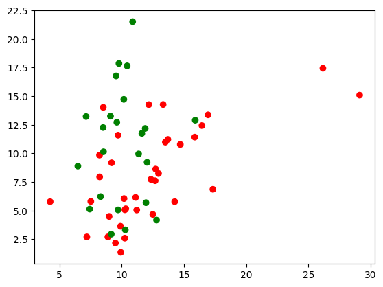

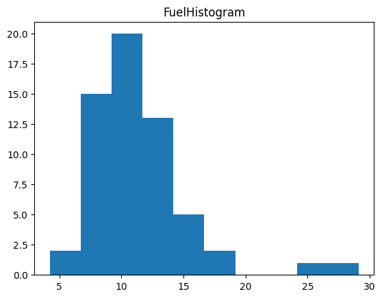

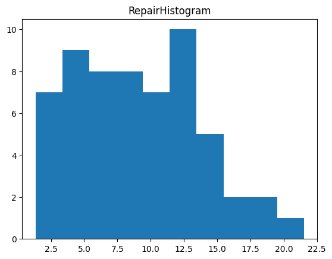

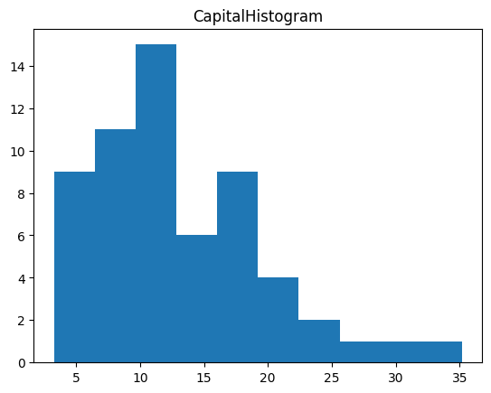

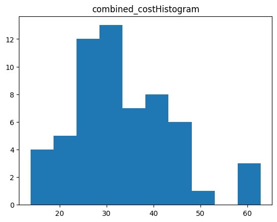

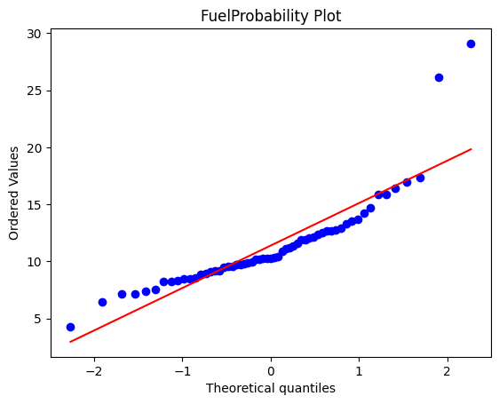

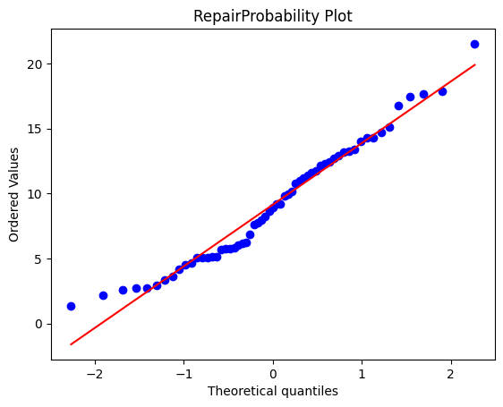

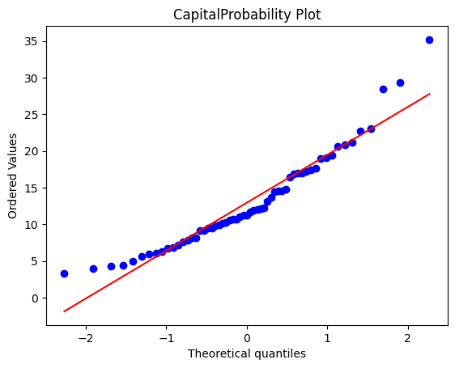

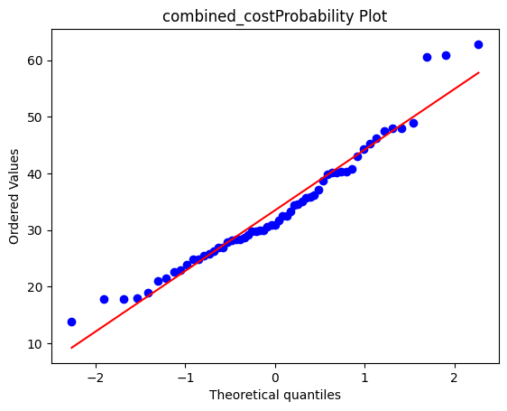

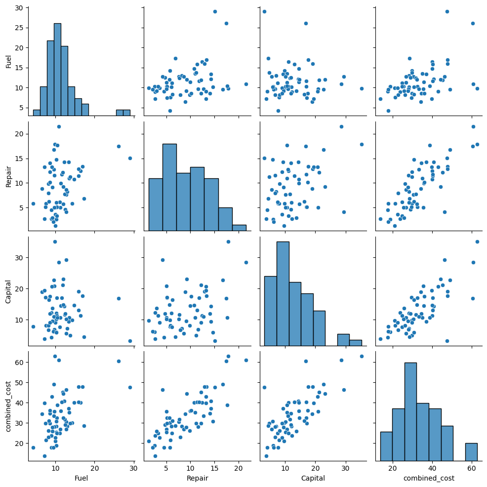

[output not shown]

```python
#Q5
import numpy as np
import pandas as pd
import matplotlib.pyplot as plt

#A
dairy = pd.read_csv(r'/Volumes/T7 Shield APFS/Data-319-Model-Data-Based-Methods/Notes and Material/MT/dairy.csv')
sample_aves = dairy.select_dtypes(include = [np.number]).mean() #Compute Numeric Column Means
print(sample_aves)

gasoline_means = dairy[dairy['Type'] == 'gasoline'].select_dtypes(include = [np.number]).mean()
print("Gasoline Truck Means: \n", gasoline_means)

diesel_means = dairy[dairy['Type'] == 'diesel'].select_dtypes(include = [np.number]).mean()
print("Diesel Truck Means: \n", diesel_means)

#B
dairy['combined_cost'] = dairy['Fuel'] + dairy['Repair'] + dairy['Capital']

max_truck = dairy.loc[dairy['combined_cost'].idxmax()]
print(f"\nMax Cost Truck: \n{max_truck}")

gas = dairy[dairy['Type'] == 'gasoline']
max_gas_truck = gas.loc[gas['combined_cost'].idxmax()]
print(f"\nMax Gasoline Truck: \n{max_gas_truck}")

die = dairy[dairy['Type'] == 'diesel']
max_die_truck = die.loc[die['combined_cost'].idxmax()]
print(f"\nMax Diesel Truck: \n{max_die_truck}")

#C
plt.scatter(dairy['Fuel'], dairy['Repair'], c = dairy['Type'].map({'gasoline': 'red', 'diesel': 'green'}))
plt.show()

#D
import seaborn as sns
#Histogram
for column in dairy.select_dtypes(include = [np.number]):
    plt.hist(dairy[column])
    plt.title(column + 'Histogram')
    plt.show()

#Probablity Plot
for column in dairy.select_dtypes(include = [np.number]):
    stats.probplot(dairy[column], plot = plt)
    plt.title(column + 'Probability Plot')
    plt.show()

#pairwise scatterplots
sns.pairplot(dairy.select_dtypes(include = [np.number]))
plt.show()
```

```python
#E
from hotelling.stats import hotelling_t2
data = dairy[['Fuel', 'Repair', 'Capital']].values

mu_0 = np.array([12, 8, 10])
mu_1 = np.array([10, 18, 10])
mu_2 = np.array([11, 9, 13])

sample_mean = np.mean(data, axis=0)
sample_cov = np.cov(data, rowvar=False)
n, p = data.shape

t2_stat_0, f_value_0, p_value_0, s = hotelling_t2(data, mu_0)
t2_stat_1, f_value_1, p_value_1, s = hotelling_t2(data, mu_1)
t2_stat_2, f_value_2, p_value_2, s = hotelling_t2(data, mu_2)

alpha = 0.05
n = len(dairy)
p = len(dairy.columns.tolist())
critical = ((p*(n-1))/(n-p)) * stats.f.ppf(1 - alpha,p,n-p)

print(f"The critical value is {critical} while the test statistic is {t2_stat_0}")
print(f"{str(abs(t2_stat_0) > critical).lower()} that we should reject the null hypothesis")
print(f"The critical value is {critical} while the test statistic is {t2_stat_1}")
print(f"{str(abs(t2_stat_1) > critical).lower()} that we reject the null hypothesis")
print(f"The critical value is {critical} while the test statistic is {t2_stat_2}")
print(f"{str(abs(t2_stat_2) > critical).lower()} that we reject the null hypothesis")

#F
S = np.cov(dairy[['Fuel', 'Repair', 'Capital']].T)
s_inv = []
xbar = np.mean(dairy[['Fuel', 'Repair', 'Capital']], axis = 0)

for i in range(3):
    s_inv.append([xbar.iloc[i] - np.sqrt(critical * S[i,i] / n), xbar.iloc[i] + np.sqrt(critical * S[i,i] / n)])

print('\n\n T^2 Confidence Intervals')
for entry in zip(dairy.columns, s_inv):
    print(f'* {entry[0]} - low  {entry[1][0]}, high {entry[1][1]}')
    width = entry[1][1] - entry[1][0]
    print(width)


bonf_a = alpha / 3
bonf_corr = []

for i in range(3):
    bonf_corr.append(stats.ttest_1samp(dairy.iloc[:,i],xbar.iloc[i]).confidence_interval(confidence_level= 1 - bonf_a))

print('\n\n Bonf Correction Intervals')
for entry in zip(dairy.columns, bonf_corr):
    print(f'* {entry[0]} - low  {entry[1][0]}, high {entry[1][1]}')
    width = entry[1][1] - entry[1][0]
    print(width)
```

```
The critical value is 12.814078886231902 while the test statistic is 13.685004819813438
true that we should reject the null hypothesis
The critical value is 12.814078886231902 while the test statistic is 397.40152372828953
true that we reject the null hypothesis
The critical value is 12.814078886231902 while the test statistic is 0.5543878178863465
false that we reject the null hypothesis


 T^2 Confidence Intervals
* Fuel - low  9.494872182946525, high 13.294958325528052
3.8000861425815273
* Repair - low  6.954995215549487, high 11.335852242077632
4.380857026528145
* Capital - low  9.845384179686004, high 16.02275141353434
6.1773672338483365


 Bonf Correction Intervals
* Fuel - low  10.086315493354629, high 12.70351501511995
2.61719952176532
* Repair - low  7.6368293858754885, high 10.654018071751633
3.0171886858761443
* Capital - low  10.806826207395362, high 15.061309385824984
4.254483178429622
```